# ICE ERO-LESA enforcement events FY12-22: Analysis of ‘landmark’ fields

UWCHR

2024-10-31

Back to index

# Data overview: “Landmark” fields

```r
options(scipen = 1000000, digits = 2)

library(pacman)

p_load(here, tidyverse, zoo, lubridate, ggplot2, plotly, gghighlight, sf, tigris, ggrepel, ggmap, tidygeocoder, viridis)

# ENCOUNTERS DATA

enc <- read_delim(here('write', 'input', 'ice_encounters_fy12-23ytd.csv.gz'), delim='|',
                  col_types = cols(aor = col_factor(),
                                   event_date = col_character(),
                                   landmark = col_character(),
                                   operation = col_factor(),
                                   processing_disposition = col_factor(),
                                   citizenship_country = col_factor(),
                                   gender = col_factor(),
                                   hashid = col_character(),
                                   id = col_number()),
                  show_col_types = FALSE)

redacted <- c('encounter_threat_level', 'alien_file_number')
redacted_text <- paste0('`', paste(unlist(redacted), collapse = '`, `'), '`')

enc <- enc %>%
  dplyr::select(-redacted)

enc <- enc %>%
  mutate(aor = factor(aor, levels = sort(levels(enc$aor))),
         event_date = as_date(event_date, format="%m/%d/%Y"),
         year = year(event_date),
         month = month(event_date, label=TRUE, abbr=TRUE),
         year_mth = zoo::as.yearmon(event_date),
         fy_quarter = as.factor(quarter(event_date, fiscal_start=10, type="year.quarter")),
         fy = as.factor(substr(fy_quarter, 1,4)),
         gender = toupper(gender),
         operation = toupper(operation),
         processing_disposition = toupper(processing_disposition),
         citizenship_country = toupper(citizenship_country))

# ARRESTS DATA

arr <- read_delim(here('write', 'input', 'ice_arrests_fy12-23ytd.csv.gz'), delim='|',
                  col_types = cols(aor = col_factor(),
                                  arrest_date = col_date(format="%m/%d/%Y"),
                                  departed_date = col_date(format="%m/%d/%Y"),
                                  apprehension_landmark = col_factor(),
                                  arrest_method = col_factor(),
                                  operation = col_factor(),
                                  processing_disposition = col_factor(),
                                  citizenship_country = col_factor(),
                                  gender = col_factor(),
                                  case_closed_date = col_date(format="%m/%d/%Y"),
                                  id = col_integer(),
                                  hashid = col_character()
                                  ))

redacted <- c('removal_threat_level', 'apprehension_threat_level', 'alien_file_number')
redacted_text <- paste0('`', paste(unlist(redacted), collapse = '`, `'), '`')

arr <- arr %>%
  dplyr::select(-all_of(redacted))

arr <- arr %>%
  mutate(aor = factor(aor, levels = sort(levels(arr$aor))),
         arrest_date = as_date(arrest_date, format="%m/%d/%Y"),
         year = year(arrest_date),
         month = month(arrest_date, label=TRUE, abbr=TRUE),
         year_mth = zoo::as.yearmon(arrest_date),
         fy_quarter = as.factor(quarter(arrest_date, fiscal_start=10, type="year.quarter")),
         fy = as.factor(substr(fy_quarter, 1,4)),
         citizenship_country = as.factor(toupper(citizenship_country)))

methods <- arr %>%
  count(arrest_method) %>%
  arrange(desc(n))

top_methods <- methods %>%
  filter(n > 10000)

arr <- arr %>%
  mutate(arrest_method_short =
           case_when(arrest_method %in%
                       unlist(top_methods$arrest_method) ~
                       as.character(arrest_method),
                     TRUE ~
                       "All others"))
```

This notebook provides an overview of `landmark` and `apprehension_landmark` fields respectively associated with ICE encounter and arrest records (the removals data does not contain a similar field).

We argue that it is important to exercise caution when interpreting these values, as they cannot be relied upon as precise locations of these events. Many records instead encode the ICE entity associated with the event; attempts to geolocate these events to the state or county level are likely to be inaccurate.

These fields appear to be composed of semi-structured data. It seems likely that values are generated via some form of auto-completion, given propagation of minor typographical errors in repeated entries, for example, the string “PORTALND NON-DETAINED ARREST” appears 446 times in the arrests dataset, while “PORTLAND NON-DETAINED ARREST” appears 0 times.

Most values appear a small number of times; a few values appear many times, especially in the encounters data.

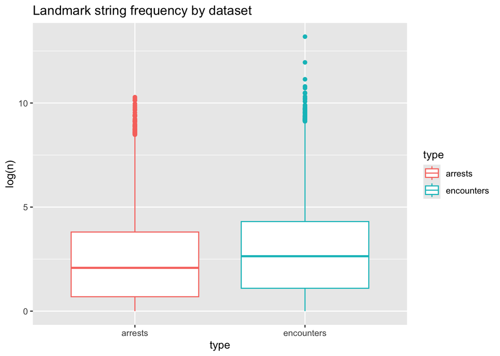

```r
enc_landmarks <- enc %>%
  filter(!is.na(landmark)) %>%
  group_by(landmark) %>%
  summarize(n = n(),
            n_aor = n_distinct(aor),
            type = "encounters") %>%
  arrange(desc(n))

arr_landmarks <- arr %>%
  filter(!is.na(apprehension_landmark)) %>%
  group_by(apprehension_landmark) %>%
  summarize(n = n(),
            n_aor = n_distinct(aor),
            type = "arrests") %>%
  rename(landmark = apprehension_landmark) %>%
  arrange(desc(n))

dat <- rbind(enc_landmarks, arr_landmarks)

b1 <- dat %>%
  ggplot(aes(x = type, y = log(n), color = type)) +
  geom_boxplot() +
  labs(title = "Landmark string frequency by dataset")

b1
```

# Encounters

The Encounters dataset contains 12549 distinct `landmark` values; or 21125 distinct combinations of `aor` and `landmark`.

## Missingness

A total of 1528342 or 27.66% of encounter records are missing `landmark` values; see below for an overview of missingness over time and across ICE areas of responsibility.

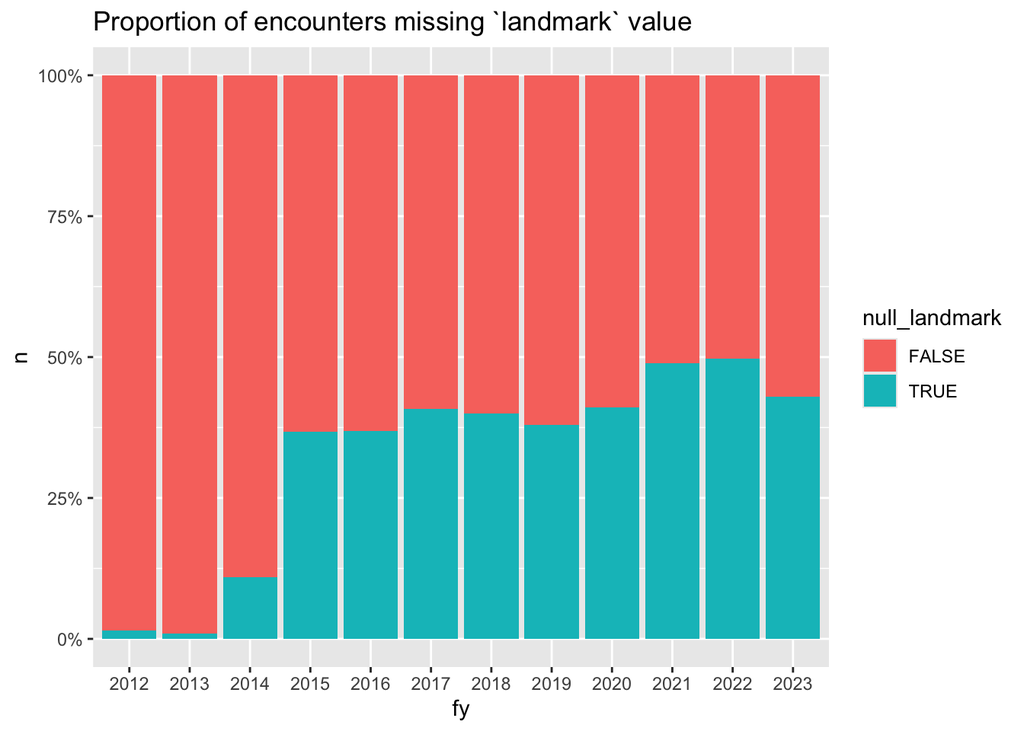

```r
p1 <- enc %>%
  mutate(null_landmark = is.na(landmark)) %>%
  count(null_landmark, fy) %>%
  ggplot(aes(x = fy, y = n, fill = null_landmark)) +
  geom_col(position="fill") +
  scale_y_continuous(labels = scales::percent) +
  labs(title = "Proportion of encounters missing `landmark` value")

p1
```

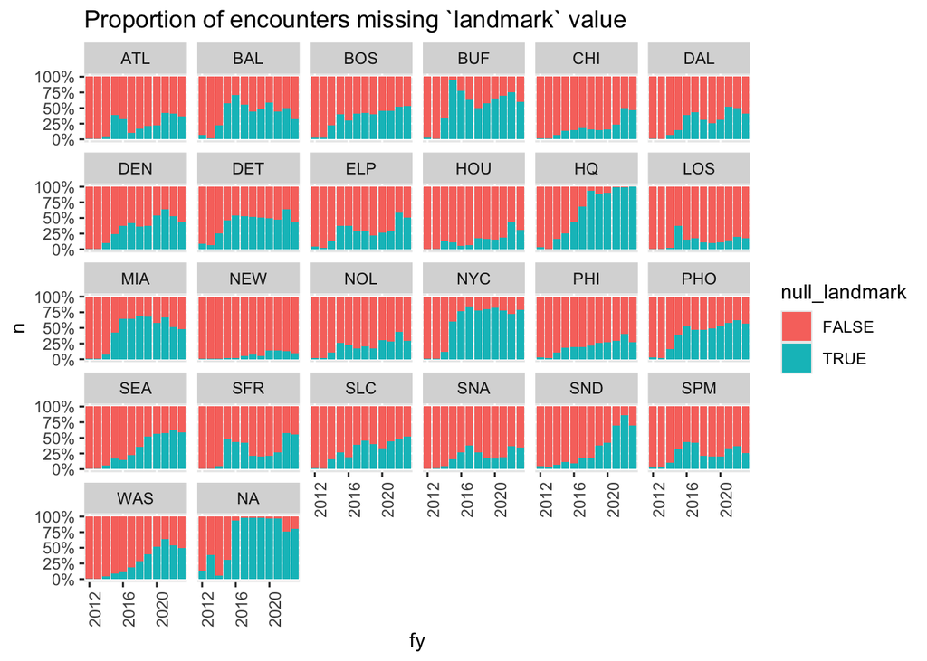

```r
p2 <- enc %>%
  mutate(null_landmark = is.na(landmark)) %>%
  count(null_landmark, fy, aor) %>%
  ggplot(aes(x = fy, y = n, fill = null_landmark)) +
  geom_col(position="fill") +
  scale_y_continuous(labels = scales::percent) +
  scale_x_discrete(breaks=seq(2012, 2022, 4)) +
  theme(axis.text.x = element_text(angle = 90, vjust = 1, hjust=1)) +
  facet_wrap(~aor) +
  labs(title = "Proportion of encounters missing `landmark` value")

p2
```

## Most common encounter `landmark` values

See below a table of the ten most common encounter `landmark` values. Note the top two values are associated with ICE “Interoperability” centers in Los Angeles, CA (Los Angeles AOR), and Batavia, NY (Buffalo AOR), which utilized nationwide databases to identify potential targets for ICE enforcement actions in the context of “Secure Communities” and other ICE programs; it is possible that these targets may not even be located in the respective states or AORs of these interoperability centers. See the Encounters notebook for an overview of rates of encounters per AOR, which shows that the LOS and BUF regions had extremely high rates of encounters during periods when these `landmark` values predominate.

Note also the inclusion of landmarks associated with enforcement programs at either the state or AOR-level (“SECURE COMMUNITIES NEW YORK”). Finally, other values are denoted as “GENERAL AREA, NON-SPECIFIC”; these will be discussed in more detail below in the context of the arrests dataset.

```r
dat <- enc %>%
  filter(!is.na(landmark)) %>%
  count(landmark) %>%
  arrange(desc(n)) %>%
  head(10)

knitr::kable(dat)
```

| landmark | n |
| --- | --- |
| SC INTEROPERABILITY LAFO | 534558 |
| BATAVIA INTEROPERABILITY REGIONAL CENTER NY STATE | 155265 |
| CHICAGO DEPORT CENTER SECURE COMMUNITIES, IL | 68959 |
| CAP - MARICOPA COUNTY SHERIFFS OFFICE JAIL | 48899 |
| WSM GENERAL AREA, NON-SPECIFIC | 45155 |
| HARRIS COUNTY JAIL, HOUSTON, TX | 35808 |
| GCJ GENERAL AREA, NON-SPECIFIC | 35749 |
| SECURE COMMUNITIES NEW YORK | 35147 |
| DALLAS COUNTY GENERAL AREA | 29991 |
| TEXAS DEPT OF CRIMINAL JUSTICE, WALKER CO | 27724 |

# Arrests

The Arrests dataset contains 10619 distinct `apprehension_landmark` values; or 14622 distinct combinations of `aor` and `apprehension_landmark`.

## Missingness

A total of 55999 or 3.22% of arrest records are missing `apprehension_landmark` values; see below for an overview of missingness over time and among ICE areas of responsibility.

Note especially that specific categories of arrests, including “ERO Reprocessed Arrest” and “Inspections” are significantly more likely to be missing `apprehension_landmark` values.

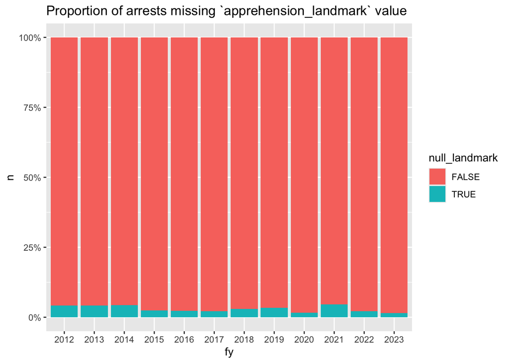

```r
p1 <- arr %>%
  mutate(null_landmark = is.na(apprehension_landmark)) %>%
  count(null_landmark, fy) %>%
  ggplot(aes(x = fy, y = n, fill = null_landmark)) +
  geom_col(position="fill") +
  scale_y_continuous(labels = scales::percent) +
  labs(title = "Proportion of arrests missing `apprehension_landmark` value")

p1
```

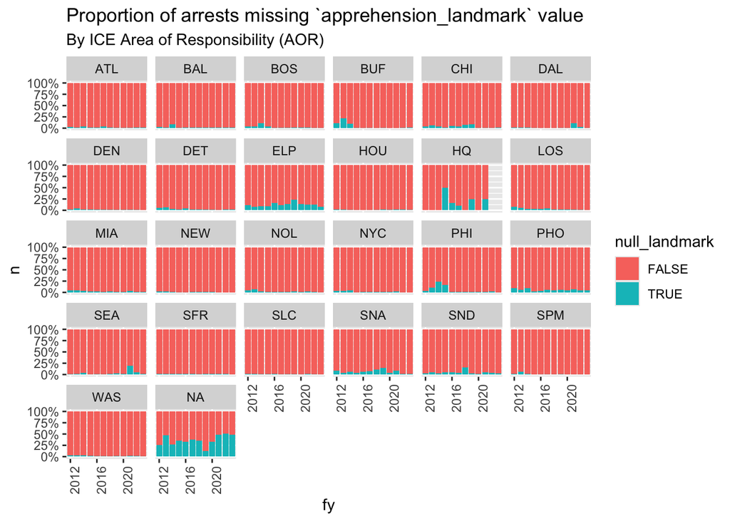

```r
p2 <- arr %>%
  mutate(null_landmark = is.na(apprehension_landmark)) %>%
  count(null_landmark, fy, aor) %>%
  ggplot(aes(x = fy, y = n, fill = null_landmark)) +
  geom_col(position="fill") +
  scale_y_continuous(labels = scales::percent) +
  scale_x_discrete(breaks=seq(2012, 2022, 4)) +
  theme(axis.text.x = element_text(angle = 90, vjust = 1, hjust=1)) +
  facet_wrap(~aor) +
  labs(title = "Proportion of arrests missing `apprehension_landmark` value",
       subtitle = "By ICE Area of Responsibility (AOR)")

p2
```

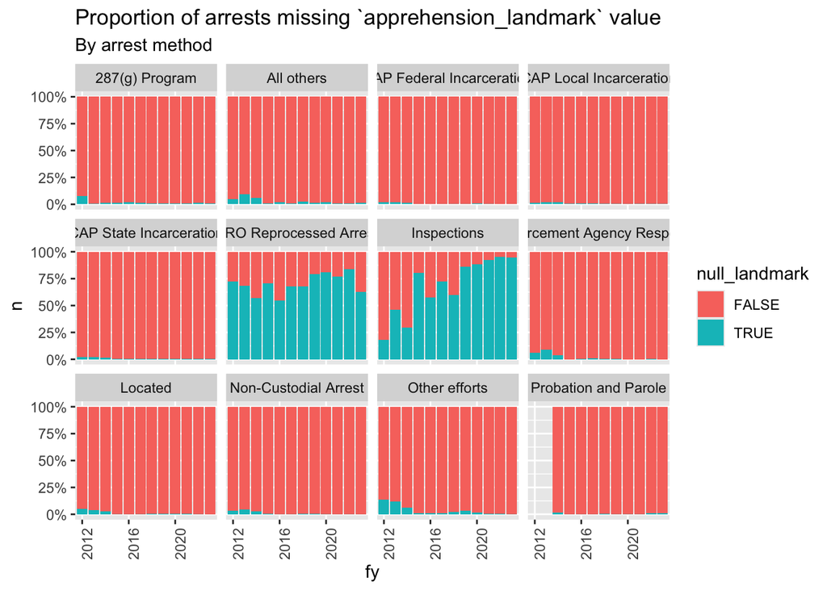

```r
p3 <- arr %>%
  mutate(null_landmark = is.na(apprehension_landmark)) %>%
  count(null_landmark, fy, arrest_method_short) %>%
  ggplot(aes(x = fy, y = n, fill = null_landmark)) +
  geom_col(position="fill") +
  scale_y_continuous(labels = scales::percent) +
  scale_x_discrete(breaks=seq(2012, 2022, 4)) +
  theme(axis.text.x = element_text(angle = 90, vjust = 1, hjust=1)) +
  facet_wrap(~arrest_method_short) +
  labs(title = "Proportion of arrests missing `apprehension_landmark` value",
       subtitle = "By arrest method")

p3
```

## Most common arrests `apprehension_landmark` values

See below a table of the ten most common arrest `apprehension_landmark` values. In contrast with the encounters landmarks described above, these appear to map more reliably to county or state-level landmarks; however, see below for a discussion of concerns related to geolocation of these values.

```r
dat <- arr %>%
  filter(!is.na(apprehension_landmark)) %>%
  count(apprehension_landmark) %>%
  arrange(desc(n)) %>%
  head(10)

knitr::kable(dat)
```

| apprehension_landmark | n |
| --- | --- |
| HARRIS COUNTY JAIL, HOUSTON, TX | 29191 |
| DALLAS COUNTY GENERAL AREA | 27236 |
| LOS ANGELES COUNTY GENERAL AREA, NON-SPECIFIC | 25106 |
| TEXAS DEPT OF CRIMINAL JUSTICE, WALKER CO | 25093 |
| CAP - MARICOPA COUNTY SHERIFFS OFFICE JAIL | 21254 |
| LOS ANGELES COUNTY JAIL, LOS ANGELES, CA | 19391 |
| NDD - 26 FEDERAL PLAZA NY, NY | 17915 |
| ICE ERO NEWARK | 16517 |
| VAL VERDE COUNTY JAIL | 15593 |
| DAL COUNTY JAIL | 13846 |

## Problematic `apprehension_landmark` values

### ICE Field Offices and programs

However, note the value “ICE ERO NEWARK”, which denotes an arrest associated with Enforcement and Removal Operations out of the Newark Field Office; this Field Office has jurisdiction over the entire state of New Jersey, and we believe it would likely be inaccurate to associate these arrests with the city of Newark or Essex County, NJ. Additionally, the value “NDD - 26 FEDERAL PLAZA NY, NY” denotes the “non-detained docket” of ICE’s New York City Field Office; it is unclear that this should be taken as the precise location of an arrest, versus an administrative category.

Values denoting ICE field offices or programs (e.g. “FUGITIVE OPERATIONS”, “STREET ARREST”) rather than locations are also common throughout the dataset; attempts to geolocate and interpret these values as precise arrest locations will likely lead to systematic over-representation of geographic divisions associated with ICE field offices.

For example, 1749 records with `apprehension_landmark` value “SEA CAP”, denoting Criminal Alien Program arrests out of the Seattle field office, should likely not be interpreted as associated with the city of Seattle or King County, as these arrests could have taken place anywhere in the Seattle Area of Responsibility.

```r
ldmk_aor_count <- arr %>%
  group_by(apprehension_landmark) %>%
  summarize(n = n(),
            n_aor = n_distinct(aor)) %>%
  arrange(desc(n_aor))

select_nonspecific <- c("LICENSING UNIT/STATE POLICE", "287g", "at-large", "California Healthcare Facility", "CALIFORNIA HIGHWAY PATROL", "CAP ACI", "CIS REFERRAL", "FEDERAL DETENTION CENTER (FDC)", "FIELD ARREST", "FTC CI (Federal Transfer Center)", "FTM-JCART", "FTM-VCAS", "FUG - NON FUGITIVE", "FUGITIVE OPERATIONS", "FUGITIVE SOUTH TEAM ARRESTS", "FUGOP", "FUGOPS", "STREET ARREST", "STREET ARRESTS", "U.S. Marshalls Service", "U.S. Marshals", "U.S. Marshals Service", "U.S. MARSHALS SERVICE", "U.S. PROBATION OFFICE", "UNITED STATES MARSHALL SERVICE", "UNITED STATES PROBATION & PAROLE", "UNITED STATES PROBATION", "US 281 TO FM 493 EXP 83 NORTH TO FM 490", "US DISTRICT COURT", "US MARSHALLS", "US Marshals TF", "USCIS ARREST", "USCIS REFERRALS")

dat <- arr %>%
  filter(apprehension_landmark %in% select_nonspecific) %>%
  group_by(apprehension_landmark) %>%
  summarize(n = n(),
            n_aor = n_distinct(aor)) %>%
  arrange(desc(n)) %>%
  head(15)

knitr::kable(dat)
```

| apprehension_landmark | n | n_aor |
| --- | --- | --- |
| FUGITIVE OPERATIONS | 9616 | 13 |
| FUGITIVE SOUTH TEAM ARRESTS | 1504 | 6 |
| FEDERAL DETENTION CENTER (FDC) | 1231 | 3 |
| CAP ACI | 462 | 3 |
| FUGOPS | 218 | 2 |
| UNITED STATES MARSHALL SERVICE | 210 | 2 |
| US DISTRICT COURT | 174 | 2 |
| FTM-VCAS | 111 | 2 |
| FTC CI (Federal Transfer Center) | 103 | 1 |
| FUG - NON FUGITIVE | 86 | 1 |
| STREET ARREST | 76 | 3 |
| FTM-JCART | 63 | 1 |
| California Healthcare Facility | 49 | 1 |
| FIELD ARREST | 39 | 1 |
| 287g | 36 | 1 |

### “GENERAL AREA, NON-SPECIFIC”

```r
nonspecific_str <- unique(arr$apprehension_landmark[grep('[A-Z]{3} GENERAL AREA, NON-SPECIFIC', arr$apprehension_landmark)])

aor_dat <- arr %>%
  mutate(nonspecific = apprehension_landmark %in% nonspecific_str) %>%
  count(nonspecific, fy, aor)

method_dat <- arr %>%
  mutate(nonspecific = apprehension_landmark %in% nonspecific_str) %>%
  count(nonspecific, fy, arrest_method_short)
```

A significant number of `apprehension_landmark` values include the phrase “GENERAL AREA, NON-SPECIFIC”; when excluding values that also describe a state or county by name, these amount to 293824 records or 16.88% of the arrests dataset.

The majority of these values follow a regular format of a three-letter alphabetic code followed by “GENERAL AREA, NON-SPECIFIC”. We believe that these three-letter alphabetic codes denote ICE field offices or sub-field offices; this observation is derived from our [analysis of DHS I-213](https://uwchr.github.io/i-213-analysis/) “Record of Deportable/Inadmissible Alien” forms for the Seattle Area of Responsibility, which include a “Location Code” field which appears to encode the DHS field office and sub-field office associated with each apprehension, e.g. “SEA/RIC” for Seattle field office, Richland, WA sub-field office. Although some maps of ICE sub-field offices have been published, we are unaware of any comprehensive source of information regarding interpretation of sub-field office codes or their respective jurisdictions. Our analysis of I-213 forms for the Seattle AOR suggests that sub-field offices may conduct arrests in multiple counties or states.

Crucially, the quantity of records with these explicitly non-specific `apprehension_landmark` values varies over time and between ICE AORs and programs (by `arrest_method`), as observed below. Note this does not include other `apprehension_landmark` values which cannot be precisely geolocated.

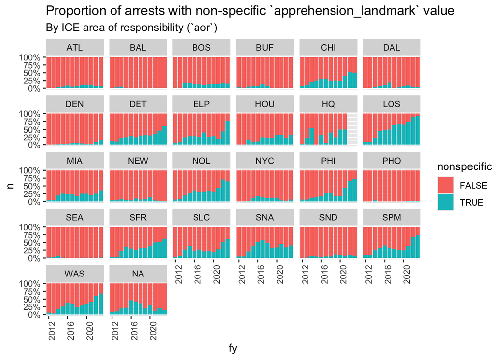

```r
p1 <- aor_dat %>%
  ggplot(aes(x = fy, y = n, fill = nonspecific)) +
  geom_col(position="fill") +
  scale_y_continuous(labels = scales::percent) +
  scale_x_discrete(breaks=seq(2012, 2022, 4)) +
  theme(axis.text.x = element_text(angle = 90, vjust = 1, hjust=1)) +
  facet_wrap(~aor) +
  labs(title = "Proportion of arrests with non-specific `apprehension_landmark` value",
       subtitle = "By ICE area of responsibility (`aor`)")

p1
```

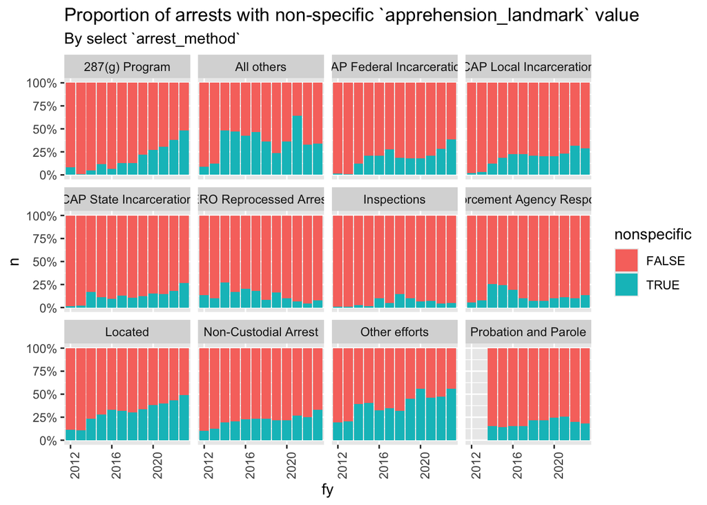

```r
p2 <- method_dat %>%
  ggplot(aes(x = fy, y = n, fill = nonspecific)) +
  geom_col(position="fill") +
  scale_y_continuous(labels = scales::percent) +
  scale_x_discrete(breaks=seq(2012, 2022, 4)) +
  theme(axis.text.x = element_text(angle = 90, vjust = 1, hjust=1)) +
  facet_wrap(~arrest_method_short) +
  labs(title = "Proportion of arrests with non-specific `apprehension_landmark` value",
       subtitle = "By select `arrest_method`")

p2
```

## Text analysis

Although we caution against interpreting landmark values as precise encounter/arrest locations, we do not suggest that these fields are not important for quantitative or qualitative analysis. For example, see below a very simple example of textual analysis suggestive of a trend of decreasing arrests involving local and county jails nationwide, alongside a corresponding decrease in arrests via ICE’s “CAP Local Incarceration” program.

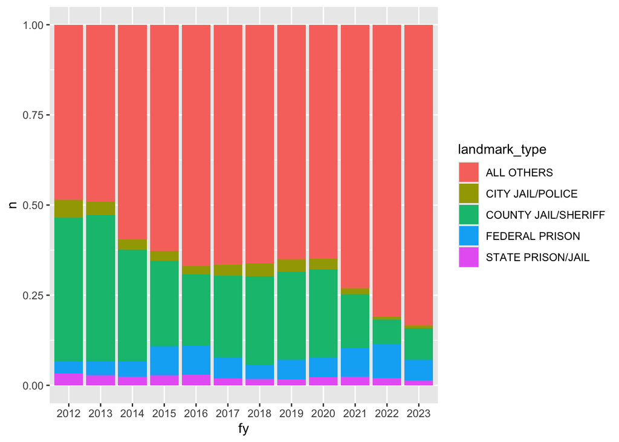

```r
arr <- arr %>%
  mutate(
    landmark_type = case_when(
      str_detect(apprehension_landmark, "COUNTY JAIL") ~ "COUNTY JAIL/SHERIFF",
      str_detect(apprehension_landmark, "PARISH JAIL") ~ "COUNTY JAIL/SHERIFF",
      str_detect(apprehension_landmark, "CO\\.? JAIL") ~ "COUNTY JAIL/SHERIFF",
      str_detect(apprehension_landmark, "SHERIFF|SHERRIFF") ~ "COUNTY JAIL/SHERIFF",
      str_detect(apprehension_landmark, "COUNTY PRISON") ~ "COUNTY JAIL/SHERIFF",
      str_detect(apprehension_landmark, "CITY JAIL") ~ "CITY JAIL/POLICE",
      str_detect(apprehension_landmark, "POLICE") ~ "CITY JAIL/POLICE",
      str_detect(apprehension_landmark, "PD") ~ "CITY JAIL/POLICE",
      str_detect(apprehension_landmark, "STATE PRISON") ~ "STATE PRISON/JAIL",
      str_detect(apprehension_landmark, "STATE JAIL") ~ "STATE PRISON/JAIL",
      str_detect(apprehension_landmark, "DEPT\\.? OF CORRECTIONS") ~ "STATE PRISON/JAIL",
      str_detect(apprehension_landmark, "DEPARTMENT OF CORRECTIONS") ~ "STATE PRISON/JAIL",
      str_detect(apprehension_landmark, "\\bDOC\\b") ~ "STATE PRISON/JAIL",
      str_detect(apprehension_landmark, "FEDERAL") ~ "FEDERAL PRISON",
      str_detect(apprehension_landmark, "\\bBOP\\b") ~ "FEDERAL PRISON",
      str_detect(apprehension_landmark, "FCI") ~ "FEDERAL PRISON",
      TRUE ~ "ALL OTHERS"
      ))

p1 <- arr %>%
  count(fy, landmark_type) %>%
  ggplot(aes(x = fy, y = n, fill = landmark_type)) +
  geom_col(position="fill")

p1
```

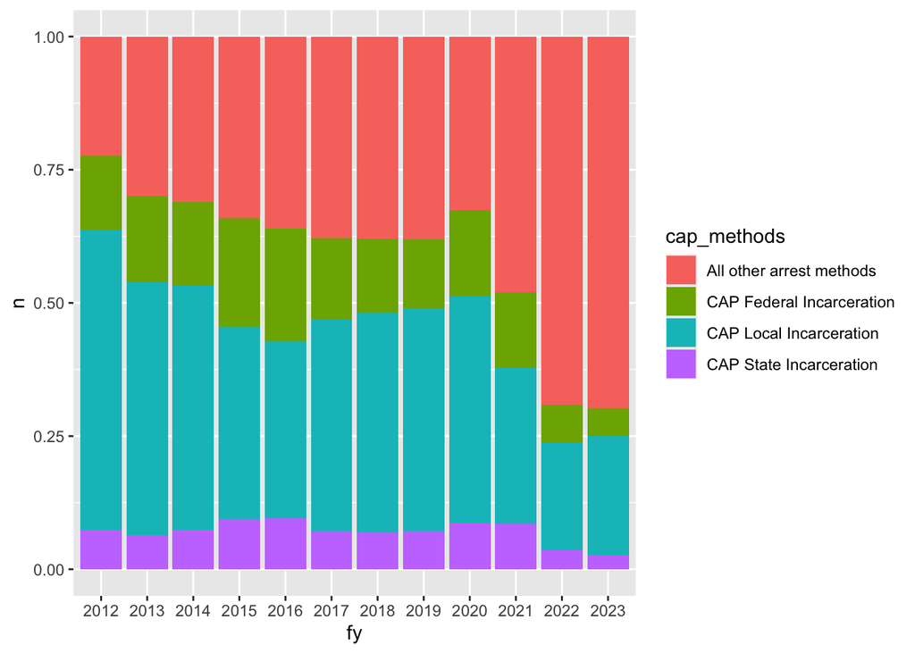

```r
p2 <- arr %>%
  mutate(cap_methods = case_when(
    str_detect(arrest_method, "CAP") ~ arrest_method,
    !str_detect(arrest_method, "CAP") ~ "All other arrest methods"
  )) %>%
  count(fy, cap_methods) %>%
  ggplot(aes(x = fy, y = n, fill = cap_methods)) +
  geom_col(position="fill")

p2
```

Increase in values connoting “non-detained docket” arrests (“NDD”):

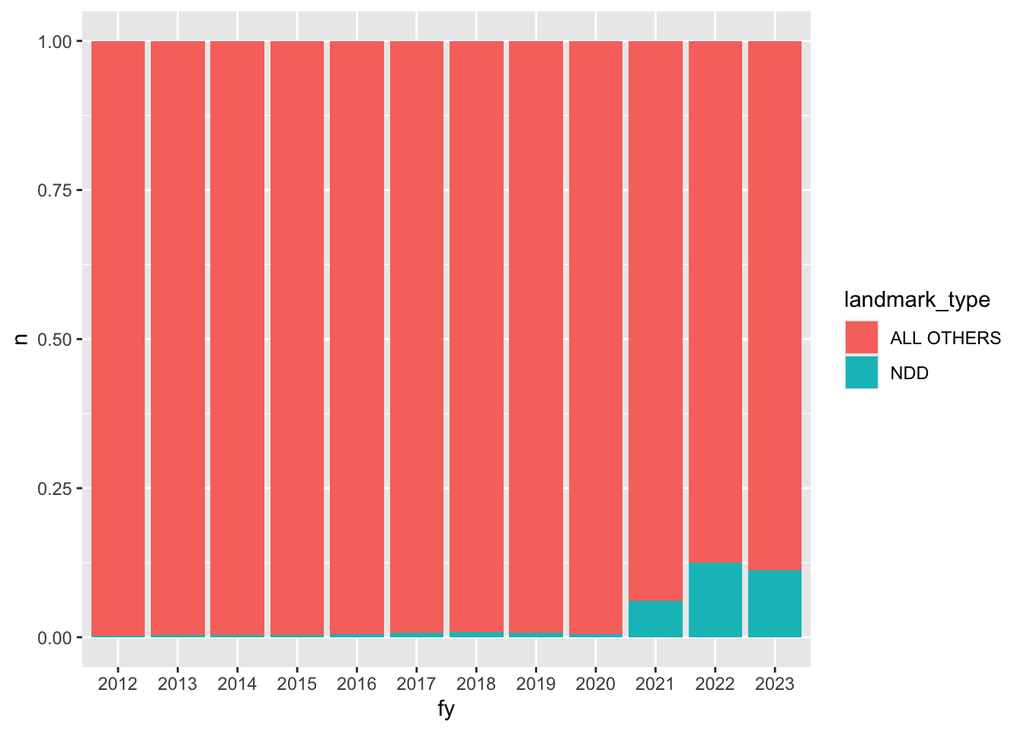

```r
arr <- arr %>%
  mutate(
    landmark_type = case_when(
      str_detect(apprehension_landmark, "NONDETAINED") ~ "NDD",
      str_detect(apprehension_landmark, "NON DETAINED") ~ "NDD",
      str_detect(apprehension_landmark, "NDD") ~ "NDD",
      str_detect(apprehension_landmark, "NON\\-DETAINED") ~ "NDD",
      TRUE ~ "ALL OTHERS"
      ))

p1 <- arr %>%
  count(fy, landmark_type) %>%
  ggplot(aes(x = fy, y = n, fill = landmark_type)) +
  geom_col(position="fill")

p1
```

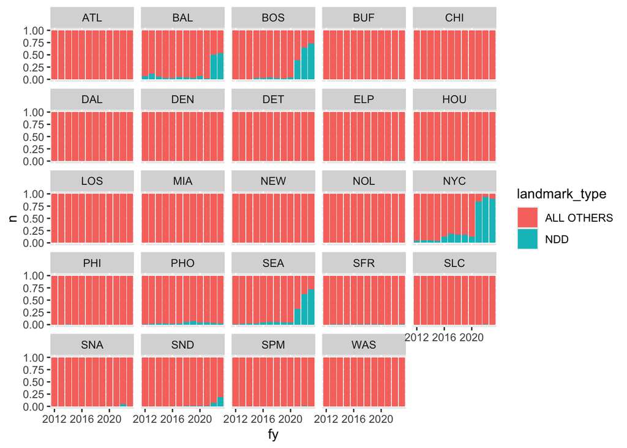

```r
p2 <- arr %>%
  filter(!is.na(aor),
         !aor == "HQ",
         !is.na(apprehension_landmark)) %>%
  count(fy, aor, landmark_type) %>%
  ggplot(aes(x = fy, y = n, fill = landmark_type)) +
  geom_col(position="fill") +
  facet_wrap(~aor) +
  scale_x_discrete(breaks=seq(2012, 2022, 4))

p2
```

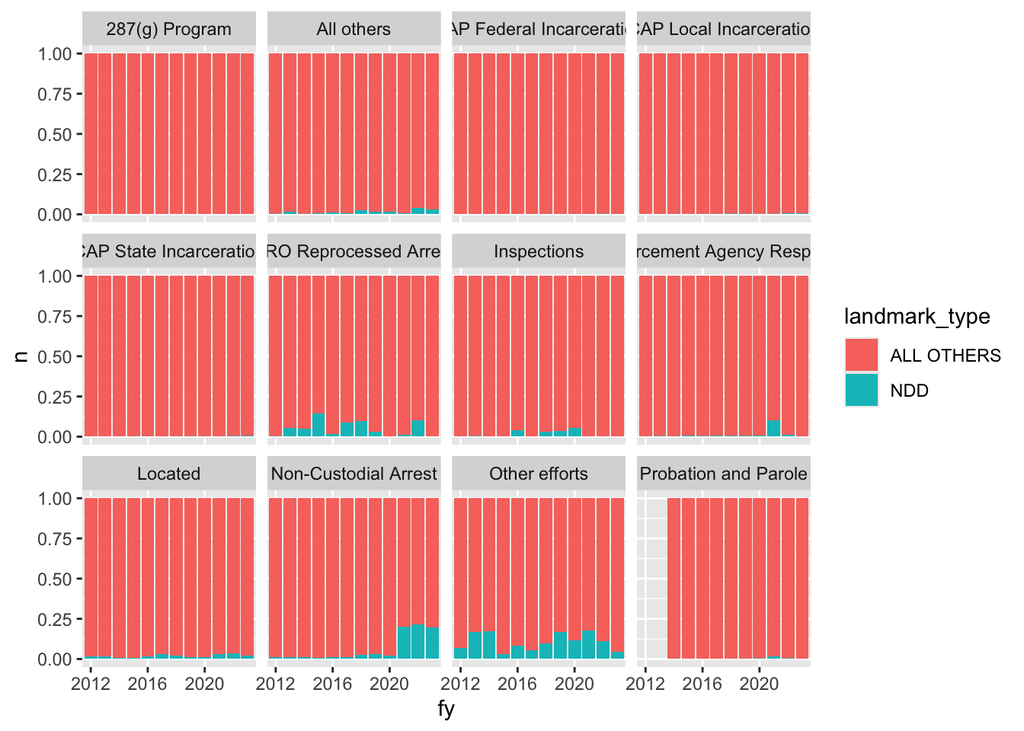

```r
p3 <- arr %>%
  filter(!is.na(aor),
         !aor == "HQ",
         !is.na(apprehension_landmark)) %>%
  count(fy, arrest_method_short, landmark_type) %>%
  ggplot(aes(x = fy, y = n, fill = landmark_type)) +
  geom_col(position="fill") +
  facet_wrap(~arrest_method_short) +
  scale_x_discrete(breaks=seq(2012, 2022, 4))

p3
```

## Top 5 `apprehension_landmark` per `area_of_responsibility`

```r
tab1 <- arr %>% count(area_of_responsibility, apprehension_landmark) %>% arrange(area_of_responsibility, desc(n)) %>% group_by(area_of_responsibility) %>%  slice_head(n=5)

knitr::kable(tab1)
```

| area_of_responsibility | apprehension_landmark | n |
| --- | --- | --- |
| Atlanta Area of Responsibility | ATLANTA, GA | 12221 |
| Atlanta Area of Responsibility | GWINNETT COUNTY JAIL - 287(G) | 11782 |
| Atlanta Area of Responsibility | D. RAY JAMES | 7027 |
| Atlanta Area of Responsibility | MECKLENBURG COUNTY, NC | 5507 |
| Atlanta Area of Responsibility | COBB COUNTY JAIL - 287(G) | 3724 |
| Baltimore Area of Responsibility | BALTIMORE CITY MD | 2883 |
| Baltimore Area of Responsibility | NON DETAINED ENCOUNTERS AT BAL ERO | 2279 |
| Baltimore Area of Responsibility | PRINCE GEORGE’S COUNTY MD | 1258 |
| Baltimore Area of Responsibility | MONTGOMERY COUNTY MD | 1167 |
| Baltimore Area of Responsibility | BALTIMORE COUNTY MD | 1019 |
| Boston Area of Responsibility | NON-DETAINED AND JUVENILE | 8896 |
| Boston Area of Responsibility | FUGITIVE OPERATIONS MA | 4896 |
| Boston Area of Responsibility | POM GENERAL AREA, NON-SPECIFIC | 1974 |
| Boston Area of Responsibility | HAR GENERAL AREA, NON-SPECIFIC | 1657 |
| Boston Area of Responsibility | HILLSBOROUGH COUNTY NH | 1580 |
| Buffalo Area of Responsibility | WENDE CORRECTIONAL FACILITY | 5046 |
| Buffalo Area of Responsibility | ERIE COUNTY | 1392 |
| Buffalo Area of Responsibility | ORLEANS CORRECTIONAL FACILITY | 975 |
| Buffalo Area of Responsibility | NA | 760 |
| Buffalo Area of Responsibility | FEDERAL CORRECTIONAL INSTITUTE RAY BROOK | 711 |
| Chicago Area of Responsibility | CHI GENERAL AREA, NON-SPECIFIC | 8604 |
| Chicago Area of Responsibility | INP GENERAL AREA, NON-SPECIFIC | 7243 |
| Chicago Area of Responsibility | MARION COUNTY SHERIFF’S OFFICE, INDIANAPOLIS, INDIANA | 4237 |
| Chicago Area of Responsibility | NA | 3901 |
| Chicago Area of Responsibility | LOUISVILLE FUGITIVE OPS ARREST | 3344 |
| Dallas Area of Responsibility | DALLAS COUNTY GENERAL AREA | 26586 |
| Dallas Area of Responsibility | DAL COUNTY JAIL | 13744 |
| Dallas Area of Responsibility | BOP GILES W DALBY | 7670 |
| Dallas Area of Responsibility | GPC CI (Great Plains Correctional Center) | 5371 |
| Dallas Area of Responsibility | OKLAHOMA CITY ICE ERO SUB-OFFICE | 5189 |

[output cut: 105 more lines]

## Top 5 `apprehension_landmark` per `arrest_method_short`

```r
tab2 <- arr %>% count(arrest_method_short, apprehension_landmark) %>% arrange(arrest_method_short, desc(n)) %>% group_by(arrest_method_short) %>%  slice_head(n=5)

knitr::kable(tab2)
```

| arrest_method_short | apprehension_landmark | n |
| --- | --- | --- |
| 287(g) Program | GWINNETT COUNTY JAIL - 287(G) | 11829 |
| 287(g) Program | HARRIS COUNTY JAIL, HOUSTON, TX | 4854 |
| 287(g) Program | PRINCE WILLIAM/MANASSAS REGIONAL JAIL - VA | 4548 |
| 287(g) Program | COBB COUNTY JAIL - 287(G) | 3717 |
| 287(g) Program | 287G COLLIER FMY ERO PROGRAM | 3339 |
| All others | CIS REFERAL, MIAMI | 1784 |
| All others | LVG GENERAL AREA, NON-SPECIFIC | 492 |
| All others | NA | 484 |
| All others | MIAMI ASYLUM REFFERAL | 479 |
| All others | JAK GENERAL AREA, NON-SPECIFIC | 416 |
| CAP Federal Incarceration | VAL VERDE COUNTY JAIL | 15506 |
| CAP Federal Incarceration | BOP FEDERAL DETENTION CENTER, HOUSTON, TX | 11597 |
| CAP Federal Incarceration | BOP GILES W DALBY | 7711 |
| CAP Federal Incarceration | USBOP CI-MOSHANNON VALLEY | 7450 |
| CAP Federal Incarceration | TAFT FEDERAL CORRECTIONAL INSTITUTION | 7096 |
| CAP Local Incarceration | HARRIS COUNTY JAIL, HOUSTON, TX | 24240 |
| CAP Local Incarceration | CAP - MARICOPA COUNTY SHERIFFS OFFICE JAIL | 21007 |
| CAP Local Incarceration | LOS ANGELES COUNTY JAIL, LOS ANGELES, CA | 17441 |
| CAP Local Incarceration | DAL COUNTY JAIL | 13656 |
| CAP Local Incarceration | DALLAS COUNTY GENERAL AREA | 12068 |
| CAP State Incarceration | TEXAS DEPT OF CRIMINAL JUSTICE, WALKER CO | 24997 |
| CAP State Incarceration | WENDE CORRECTIONAL FACILITY | 5182 |
| CAP State Incarceration | CALIPATRIA STATE PRISON | 3460 |
| CAP State Incarceration | COLORADO DEPARTMENT OF CORRECTIONS | 3096 |
| CAP State Incarceration | KROME SPC | 2994 |
| ERO Reprocessed Arrest | NA | 32674 |
| ERO Reprocessed Arrest | PIC GENERAL AREA, NON-SPECIFIC | 1567 |
| ERO Reprocessed Arrest | SAN DIEGO INSPECTIONS | 1281 |
| ERO Reprocessed Arrest | DHD GENERAL AREA, NON-SPECIFIC | 1130 |
| ERO Reprocessed Arrest | HLG GENERAL AREA, NON-SPECIFIC | 888 |
| Inspections | NA | 5219 |
| Inspections | SAN DIEGO INSPECTIONS | 4700 |
| Inspections | PIT GENERAL AREA, NON-SPECIFIC | 66 |
| Inspections | HLG DISTRICT OFFICE | 60 |
| Inspections | SNA GENERAL AREA, NON-SPECIFIC | 27 |
| Law Enforcement Agency Response Unit | LEAR - ARIZONA DEPARTMENT OF PUBLIC SAFETY | 1725 |
| Law Enforcement Agency Response Unit | LEAR - PHOENIX POLICE DEPARTMENT | 1482 |
| Law Enforcement Agency Response Unit | LOS ANGELES COUNTY JAIL, LOS ANGELES, CA | 612 |
| Law Enforcement Agency Response Unit | NA | 474 |
| Law Enforcement Agency Response Unit | LEAR - OFFICE OF INVESTIGATIONS | 428 |
| Located | FUGITIVE OPERATIONS | 6662 |
| Located | LOS ANGELES COUNTY GENERAL AREA, NON-SPECIFIC | 4959 |
| Located | FUGITIVE OPERATIONS CA STATE | 4693 |
| Located | SBD GENERAL AREA, NON-SPECIFIC | 4094 |
| Located | FUGITIVE OPERATIONS MA | 3386 |
| Non-Custodial Arrest | ICE ERO NEWARK | 16376 |
| Non-Custodial Arrest | NDD - 26 FEDERAL PLAZA NY, NY | 15545 |
| Non-Custodial Arrest | DALLAS COUNTY GENERAL AREA | 10087 |
| Non-Custodial Arrest | NON-DETAINED AND JUVENILE | 9288 |
| Non-Custodial Arrest | LOS ANGELES COUNTY GENERAL AREA, NON-SPECIFIC | 6814 |
| Other efforts | CHI GENERAL AREA, NON-SPECIFIC | 2585 |
| Other efforts | Miramar ICE/ERO Sub-Office | 1304 |
| Other efforts | DALLAS COUNTY GENERAL AREA | 1074 |
| Other efforts | SEATTLE NON-DETAINED DOCKET | 994 |
| Other efforts | NDD - 26 FEDERAL PLAZA NY, NY | 780 |
| Probation and Parole | INP GENERAL AREA, NON-SPECIFIC | 670 |
| Probation and Parole | LOS ANGELES COUNTY GENERAL AREA, NON-SPECIFIC | 474 |
| Probation and Parole | KROME SPC | 441 |
| Probation and Parole | SAN DIEGO FUGOPS | 436 |
| Probation and Parole | VENTURA FUGITIVE OPERATIONS | 426 |